# ARB-USD

## ARB-USD today is +0300, 2025-09-28, 10:59:43

This crypto forecast was generated by gemini-2.0-flash API

## Daily Chart

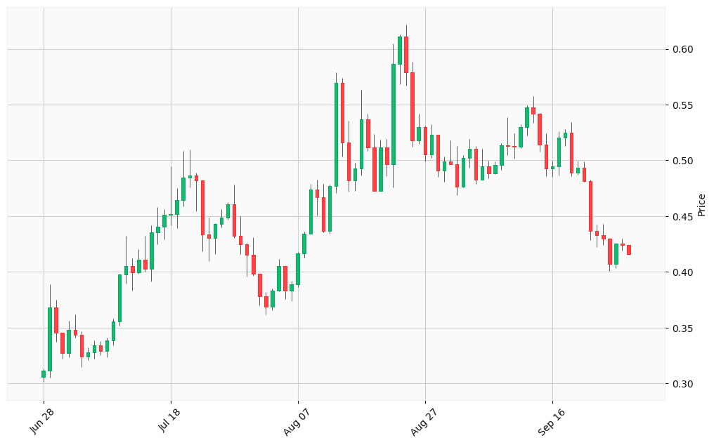

## Hourly Chart

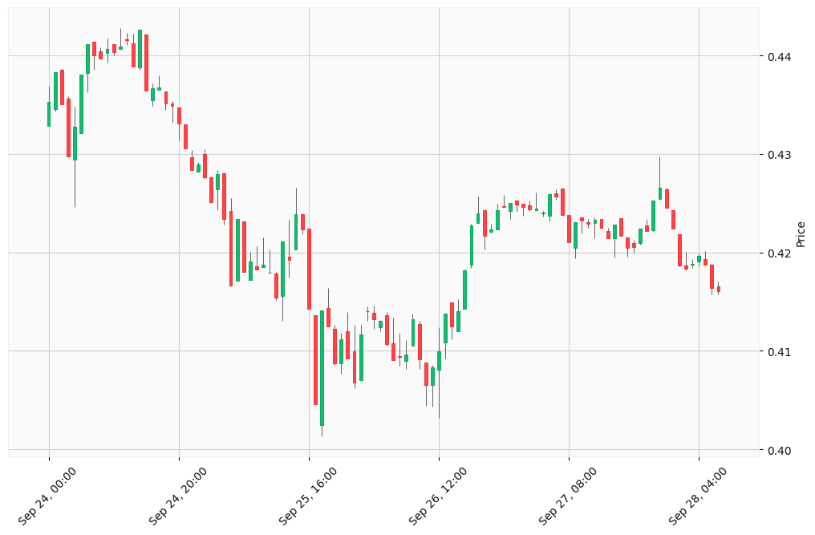

Okay, I will analyze the provided ARB-USD cryptocurrency data, incorporate market trends, and generate buy/sell signals based on the specified steps and output format.

**Analysis**

First, let’s calculate some basic technical indicators from the provided data to inform potential trading signals. I’ll focus on identifying potential support and resistance levels and momentum shifts.

Here’s the plan:

1. **Calculate Moving Averages (Daily Chart)**: I’ll calculate the 7-day and 30-day moving averages to identify short-term and medium-term trends.
2. **RSI (Daily Chart)**: Calculate the 14-day Relative Strength Index (RSI) to identify overbought or oversold conditions.
3. **Recent Price Action (Hourly Chart)**: Analyze the most recent hourly data for any immediate short-term trends or patterns.
4. **Volume Analysis**: Look for volume spikes on either chart that might indicate strong buying or selling pressure.

Based on the search results, here’s an overview of the current market context:

- **Macroeconomic Factors:** Macroeconomic indicators such as inflation, interest rates, and GDP growth can influence the cryptocurrency market. Strong GDP growth often increases investor confidence, potentially driving capital into crypto. Conversely, high inflation may lead investors to Bitcoin as a hedge.
- **Market Trends:** The cryptocurrency market is currently experiencing a decrease in market capitalization.
- **ARB-USD Specifics:** As of September 27, 2025, Arbitrum (ARB) is trading around $0.42. Recent analysis suggests sideways trading between $0.3864 and $0.4277 is likely in the short term.

**Daily Chart Analysis**

First, I’ll perform calculations on the daily chart data.

```python
import numpy as np
import pandas as pd

# Daily chart data
daily_data = [
    [0.305783, 0.31311, 0.301292, 0.311785, 109659046],
    [0.311787, 0.389058, 0.305208, 0.368471, 568827618],
    [0.368474, 0.374977, 0.33709, 0.345421, 665865882],
    [0.34542, 0.345725, 0.322007, 0.327277, 302428797],
    [0.327272, 0.356206, 0.323506, 0.347957, 481700493],
    [0.347957, 0.362178, 0.340898, 0.343838, 286591013],
    [0.343838, 0.346901, 0.314629, 0.32412, 218499936],
    [0.32412, 0.332217, 0.320812, 0.32802, 122419262],
    [0.32802, 0.338549, 0.322131, 0.334471, 134501466],
    [0.334475, 0.33819, 0.325691, 0.328916, 151462508],
    [0.328916, 0.341386, 0.323333, 0.338327, 171665096],
    [0.338327, 0.358207, 0.334445, 0.355457, 297410066],
    [0.355457, 0.398273, 0.351625, 0.397822, 354056475],
    [0.397822, 0.432146, 0.389813, 0.405556, 544887809],
    [0.405581, 0.412261, 0.383107, 0.399846, 244379653],
    [0.399846, 0.420357, 0.398603, 0.410685, 259217020],
    [0.410685, 0.432312, 0.400407, 0.402808, 390893974],
    [0.402811, 0.44153, 0.391259, 0.435352, 454887702],
    [0.435352, 0.457993, 0.424954, 0.440688, 645939996],
    [0.440681, 0.456198, 0.428897, 0.451084, 539829041],
    [0.451074, 0.494429, 0.44162, 0.45206, 861457929],
    [0.452069, 0.475348, 0.439269, 0.464735, 333183625],
    [0.464735, 0.508618, 0.458669, 0.484406, 534096669],
    [0.484406, 0.509435, 0.475496, 0.4862, 573211219],
    [0.486199, 0.48881, 0.454574, 0.481939, 621166091],
    [0.481941, 0.482145, 0.41832, 0.433706, 542427856],
    [0.433699, 0.448465, 0.409783, 0.430416, 389573414],
    [0.430416, 0.443482, 0.415696, 0.443294, 401165658],
    [0.443287, 0.456559, 0.440179, 0.44867, 232087539],
    [0.448663, 0.462615, 0.446893, 0.460757, 266460461],
    [0.460758, 0.478177, 0.430214, 0.432107, 439737006],
    [0.432128, 0.450053, 0.41574, 0.424544, 337192899],
    [0.424544, 0.425822, 0.396119, 0.415129, 323677627],
    [0.415142, 0.430826, 0.396577, 0.398393, 286009001],
    [0.398385, 0.398594, 0.369846, 0.378226, 434976380],
    [0.378216, 0.381945, 0.362133, 0.369067, 247120975],
    [0.369067, 0.384877, 0.365599, 0.383139, 161365384],
    [0.383139, 0.411517, 0.382477, 0.405183, 231272697],
    [0.405183, 0.405354, 0.376009, 0.383549, 225851477],
    [0.383555, 0.392041, 0.374053, 0.389143, 209307778],
    [0.389143, 0.418156, 0.386652, 0.416698, 253127596],
    [0.416697, 0.436127, 0.412926, 0.434058, 395751482],
    [0.434054, 0.479045, 0.43399, 0.47394, 393200300],
    [0.473946, 0.482971, 0.450612, 0.467149, 370025900],
    [0.467149, 0.479198, 0.435498, 0.43665, 498543098],
    [0.436636, 0.478396, 0.434499, 0.476835, 485201946],
    [0.476835, 0.579043, 0.47099, 0.569652, 1332481179],
    [0.569657, 0.573841, 0.503191, 0.516034, 1095329353],
    [0.516039, 0.53552, 0.472215, 0.481792, 757397762],
    [0.481761, 0.497682, 0.472395, 0.492808, 333412915],
    [0.492812, 0.563193, 0.48656, 0.536832, 852702086],
    [0.536794, 0.542067, 0.50872, 0.511443, 853603880],
    [0.511436, 0.5239, 0.472452, 0.472506, 586390932],
    [0.472507, 0.518539, 0.472426, 0.511921, 567624721],
    [0.511921, 0.519448, 0.485924, 0.49648, 435080220],
    [0.496467, 0.604449, 0.47574, 0.586299, 1310353511],
    [0.586294, 0.612999, 0.568546, 0.610767, 753805380],
    [0.610768, 0.621636, 0.566851, 0.578954, 972419750],
    [0.578959, 0.588292, 0.512109, 0.518152, 767095864],
    [0.518146, 0.541541, 0.514687, 0.530162, 612153830],
    [0.530165, 0.531119, 0.49874, 0.505332, 543511612],
    [0.505339, 0.532524, 0.501919, 0.522918, 528706939],
    [0.522921, 0.523251, 0.484995, 0.490952, 576321017],
    [0.490949, 0.503345, 0.480936, 0.499327, 269445649],
    [0.499327, 0.517697, 0.496316, 0.496627, 300491076],
    [0.496627, 0.513153, 0.468673, 0.476273, 460007623],
    [0.476299, 0.504673, 0.475583, 0.502191, 390401042],
    [0.502191, 0.518888, 0.493307, 0.510237, 321630889],
    [0.510237, 0.512834, 0.479178, 0.482675, 297530313],
    [0.482672, 0.510627, 0.482522, 0.494601, 420840284],
    [0.494601, 0.499872, 0.483802, 0.488581, 205459366],
    [0.488581, 0.498749, 0.487421, 0.496032, 182441912],
    [0.496028, 0.515493, 0.49154, 0.513208, 368861488],
    [0.513211, 0.538387, 0.504581, 0.512734, 538865013],
    [0.512734, 0.524466, 0.501842, 0.512334, 452246647],
    [0.512334, 0.532263, 0.510693, 0.530173, 366153413],
    [0.530173, 0.549703, 0.52263, 0.547517, 353093778],
    [0.547516, 0.557654, 0.533406, 0.541643, 351377164],
    [0.541633, 0.542205, 0.507876, 0.514002, 308926939],
    [0.513996, 0.524404, 0.486034, 0.492749, 433806178],
    [0.492749, 0.499697, 0.485385, 0.494936, 282417176],
    [0.494937, 0.525809, 0.48628, 0.520471, 404173399],
    [0.520475, 0.528068, 0.513168, 0.524714, 377743717],
    [0.524711, 0.534587, 0.485835, 0.489168, 406152470],
    [0.489168, 0.499698, 0.486927, 0.49337, 220789401],
    [0.493385, 0.499191, 0.480545, 0.481666, 214241666],
    [0.481666, 0.482494, 0.42835, 0.436642, 577249387],
    [0.436655, 0.442725, 0.422438, 0.432898, 320842188],
    [0.432897, 0.442908, 0.42417, 0.42972, 282957740],
    [0.42972, 0.430539, 0.400752, 0.406894, 583833829],
    [0.406895, 0.425811, 0.403137, 0.425185, 272066159],
    [0.425185, 0.429785, 0.419335, 0.42432, 116955538],
    [0.424329, 0.424329, 0.415729, 0.416076, 117682608]
]

df = pd.DataFrame(daily_data, columns=['Open', 'High', 'Low', 'Close', 'Volume'])

# Calculate 7-day and 30-day moving averages
df['MA_7'] = df['Close'].rolling(window=7).mean()
df['MA_30'] = df['Close'].rolling(window=30).mean()

# Calculate RSI (Relative Strength Index)
def calculate_rsi(data, period=14):
    delta = data.diff()
    up, down = delta.copy(), delta.copy()
    up[up < 0] = 0
    down[down > 0] = 0
    avg_gain = up.rolling(window=period).mean()
    avg_loss = abs(down.rolling(window=period).mean())
    rs = avg_gain / avg_loss
    rsi = 100 - (100 / (1 + rs))
    return rsi

df['RSI'] = calculate_rsi(df['Close'])

print(df.tail())
```

[output not shown]